# Assignment for ASML (Submodule Regression) Epiphany 2021

# General Instructions

Please go through the R notebook below, and carry out the requested tasks. You will provide all your answers directly into this .Rmd file. Add code into the R chunks where requested. You can create new chunks where required. Where text answers are requested, please add them directly into this document, typically below the R chunks, using R Markdown syntax as appropriate.

At the end, you will submit only your `knitted’ PDF version of the notebook, through Tunitin on DUO, but not the .Rmd file itself.

**Important notes**:

- Please ensure carefully that all chunks compile, and also check in the knitted PDF whether all R chunks did *actually* compile, and all images and outputs that you would like to produce have *actually* been generated. **A picture or a piece of R output which does not exist will give zero marks, even if some parts of the underlying R code would have been correct.**
- Some of the requested analyses requires running R code which is not deterministic. So, you will not have full control over the output that is finally generated in the knitted document. This is fine. It is clear that the methods under investigation carry uncertainty, which is actually part of the problem tackled in this assignment. Your analysis should, however, be robust enough so that it stays in essence correct under repeated execution of your data analysis.
- We consider a large data set! So, some calculations may take a while, and you will need to be patient. Where code contains loops, it may be a good idea to print the iteration number on the screen so that you know how far the computation has progressed. However, computations should usually not take more than a few minutes, even on an old laptop. So, if a certain computation takes too long, then change your code or methodology, rather than letting your computer struggle for hours!

# Preliminaries

We investigate a dataset introduced in a publication in *Nature* by [Alizadeh (2000)](https://www.researchgate.net/publication/12638392_Distinct_types_of_diffuse_large_B-cell_lymphoma_identified_by_gene_expression_profiling). This dataset reports gene expression profiles (7399 genes) of 240 patients with B-cell Lymphoma (a tumor that developes from B lymphocytes). The response variable corresponds to patient survival times (in years). So, this is a truly high-dimensional regression problem, with $p=7399$ predictor variables, but only $n=240$ observations.

Please use the following steps to read in the data (you may need to install R package `HCmodelSets` first).

```r
require(HCmodelSets)
data(LymphomaData)
?patient.data
```

A few initial steps need to be carried out to prepare the data for analysis. Executing

```r
names(patient.data)
```

```
[1] "x"      "time"   "status"
```

```r
dim(patient.data$x)
```

```
[1] 7399  240
```

will tell you that the matrix of predictors is given in the wrong orientation for our purposes. So, let’s define

```r
X <- t(patient.data$x)
colnames(X) <-paste("G", 1:dim(X)[2], sep="")
```

Now, we define the response variable as

```r
Time <- patient.data$time
```

# Task 1: Exploratory data analysis (10 marks)

Using appropriate graphical tools, carry out some exploratory analysis in order to get a better understanding of the data. For instance, it could be useful to provide a histogram of the response, and a scree plot for a principal component analysis of the predictor space. Additional contributions which are more creative than that are welcome. No explanations or comments are required in this task.

**Answer:**

```r
# ...

"Exploring the response variable"
```

```
[1] "Exploring the response variable"
```

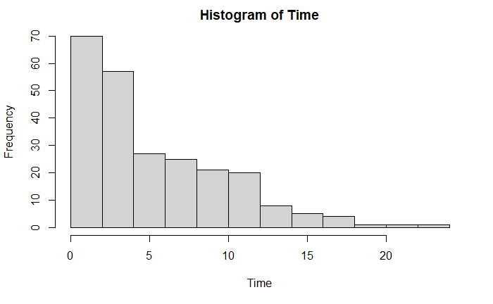

```r
#Histogram of response
hist(Time)
```

```r
#Mean
"Mean Time"
```

```
[1] "Mean Time"
```

```r
mean(Time)
```

```
[1] 5.410833
```

```r
"STD of Time"
```

```
[1] "STD of Time"
```

```r
sd(Time)
```

```
[1] 4.392515
```

```r
"sample quantiles of Time"
```

```
[1] "sample quantiles of Time"
```

```r
quantile(Time)
```

```
  0%  25%  50%  75% 100%
 1.0  1.9  3.8  8.1 22.8
```

```r
"Number of missing values in Time"
```

```
[1] "Number of missing values in Time"
```

```r
sum(is.na(Time))
```

```
[1] 0
```

```r
"Exploring the Genes (X) variable, Cant explore all as so many so use a random sample of 9 genes"
```

```
[1] "Exploring the Genes (X) variable, Cant explore all as so many so use a random sample of 9 genes"
```

```r
""
```

```
[1] ""
```

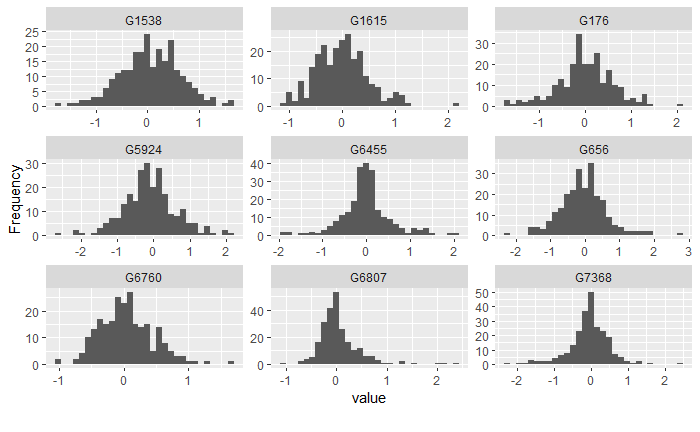

```r
xxx <- 1:7399
ind<-c(sample(xxx,9))
DataExplorer::plot_histogram(X[,ind], ncol = 3)
```

```r
#Mean
"Mean X"
```

```
[1] "Mean X"
```

```r
colMeans(X[,ind])
```

```
       G6807        G1538        G1615        G5924        G6760         G656        G6455        G7368
 0.056864333  0.056425542 -0.005778604 -0.103609958  0.049111979 -0.049136917 -0.012265771 -0.051746667
        G176
 0.006280750
```

```r
"STD of X"
```

```
[1] "STD of X"
```

```r
apply(X[,ind],2,sd)
```

```
    G6807     G1538     G1615     G5924     G6760      G656     G6455     G7368      G176
0.4242763 0.5813231 0.4931444 0.7278955 0.4128099 0.6759852 0.5737959 0.5588872 0.6133404
```

```r
"sample quantiles of X"
```

```
[1] "sample quantiles of X"
```

```r
apply(X[,ind],2,quantile)
```

```
          G6807     G1538     G1615      G5924      G6760      G656      G6455     G7368         G176
0%   -1.0860000 -1.709000 -1.069000 -2.5450000 -1.0050000 -2.168000 -1.8830000 -2.209000 -1.736000000
25%  -0.1762525 -0.309625 -0.338175 -0.5251225 -0.2456850 -0.460025 -0.2721000 -0.292850 -0.294500000
50%  -0.0166450  0.039850  0.006450 -0.1543100  0.0232800 -0.025000 -0.0070725 -0.015655 -0.001000001
75%   0.1815025  0.434000  0.286475  0.2618500  0.3139725  0.315875  0.1926725  0.250000  0.391000000
100%  2.3600000  1.634000  2.189000  2.2120000  1.6620000  2.836000  2.0710000  2.461000  2.023000000
```

```r
"Number of missing values in X"
```

```
[1] "Number of missing values in X"
```

```r
sum(is.na(X[,ind]))
```

```
[1] 0
```

```r
"Scree plot"
```

```
[1] "Scree plot"
```

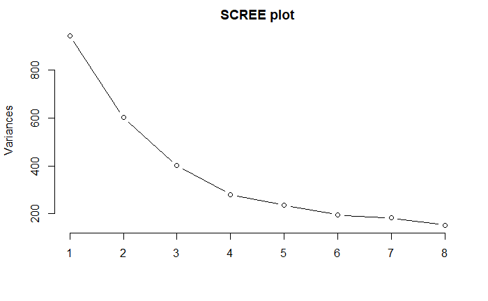

```r
pc.cr <- prcomp(X, scale. = TRUE)
screeplot(pc.cr, npcs = 8, main = "SCREE plot",type = "lines")
```

```r
"Pairs plot of 3 random genes with time"
```

```
[1] "Pairs plot of 3 random genes with time"
```

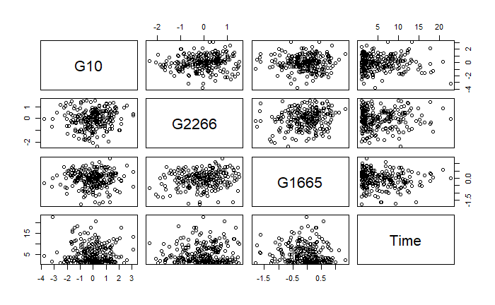

```r
xxx <- 1:7399
ind<-c(sample(xxx,3))
A = cbind(X[,ind], Time)
pairs(A)
```

```r
"Exploring the Status variable"
```

```
[1] "Exploring the Status variable"
```

```r
"Counts of the status:"
```

```
[1] "Counts of the status:"
```

```r
table(patient.data$status)
```

```
  0   1
102 138
```

```r
"NOTE I DID SCLAE THE DATA AND RUN THE CELLS BELOW, THE RESULTS DID NOT CHANGE THEREFORE i DID NOT USE SCALING IN THE END"
```

```
[1] "NOTE I DID SCLAE THE DATA AND RUN THE CELLS BELOW, THE RESULTS DID NOT CHANGE THEREFORE i DID NOT USE SCALING IN THE END"
```

```r
Unscale <- function(X,OG) {
  std <- apply(OG, 2, sd)
  meen <- colMeans(OG)
  XX <-sweep(X,2,std,`*`)
  scaled <- sweep(XX, 2, meen, `+`)

  return(scaled)
}

Scale <- function(X) {
  std <- apply(X, 2, sd)
  meen <- colMeans(X)
  XX <- sweep(X, 2, meen, `-`)
  X <-sweep(XX,2,std,"/")
  return(X)
}
```